# Practice with functions

Part 3

Module 4 A5 Week 4

## Introduction

In Part 2 of last group assignment (M4A4) we worked on writing a function that returns the Pareto cumulative distribution function, and another function that returns the Pareto quantile function.

Let us try to refine the quantile function.

## The functions up to now

Recall that the Pareto CDF $F$ and the Pareto quantile function $Q$ have the following mathematical forms.

$$F(x) = \begin{cases}
0 & x < x_0\\
1 - \left(\frac{x_0}{x} \right)^{\alpha - 1} & x \geq x_0.
\end{cases}$$

$$Q(p) = Q(p, \alpha, x_0) = {x_0}{(1-p)^{-\frac{1}{\alpha - 1}}} \quad\text{for}\quad 0 < p < 1.$$

Both $\alpha > 1$ and $x_0 \geq 1$ are numbers that have to be specified before evaluating the functions. For example with $x_0 = 5$ and $\alpha = 3$ the Pareto cumulative distribution function is

$$F(x) = \begin{cases}
0 & x < 5\\
1 - \left(\frac{5}{x} \right)^{2} & x \geq 5.
\end{cases}$$

and the Pareto quantile function is

$$Q(p) = Q(p, 3, 5) = {5}{(1-p)^{-\frac{1}{2}}} \quad\text{for}\quad 0 < p < 1.$$

Here are versions of R functions that evaluate the Pareto CDF and the Pareto quantile function.

```r
paretoCDF <- function(alpha = 2, x0 = 1, x = 1){
  cdf = rep(0, length(x))
  cdf[x > x0] <- 1 - (x0/x[x > x0])^(alpha - 1)
  return(cdf)
}
```

```r
paretoQuantile <- function(alpha, x0, p) {
q <- x0*((1-p)^(-1/(alpha-1)))
return(q)
}
```

## Adding a `lower.tail` option

Most of the quantile functions in R have an argument `lower.tail` which is either `TRUE` or `FALSE`. If `TRUE` the function returns the $p$th quantile. If `FALSE` the function returns the $1-p$th quantile, i.e., returns the value $x_p$ such that $F(x_p) = 1 - p$. This just provides a convenience for the user.

1. Modify the function `paretoQuantile` with an additional argument `lower.tail` which is by default set to `TRUE`. The function should test whether `lower.tail` is `FALSE`. If so, the function should replace $p$ by $1-p$ and then compute the quantile. Use an `if()` construct to do the test.

```r
paretoQuantile <- function(alpha, x0, p, lower.tail = TRUE) {
if (lower.tail == FALSE){
  p = 1-p
}

q <- x0*((1-p)^(-1/(alpha-1)))
return(q)
}


paretoQuantile(p = 0.98, alpha = 3, x0 =5, lower.tail = TRUE)
```

```
[1] 35.35534
```

Here are a few test cases:

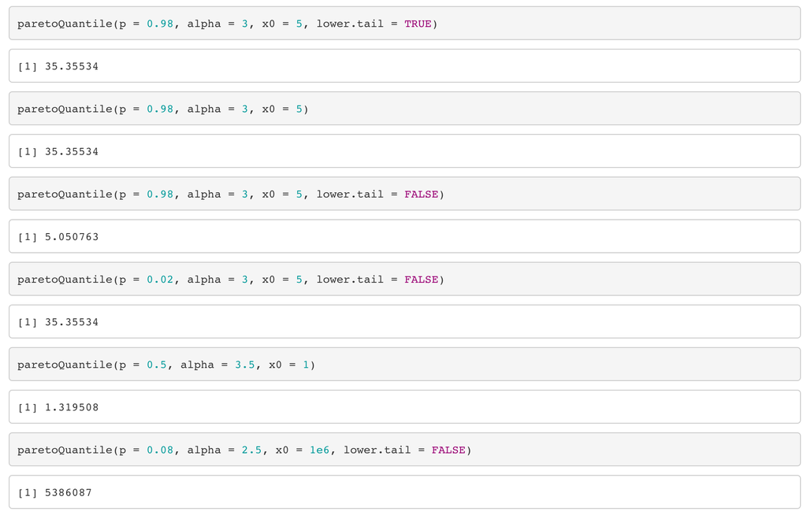

## Checking the arguments of the function

Adding checks to ensure that arguments to the function are reasonable would be helpful. In the case of the Pareto quantile function we need $0\leq p\leq 1$, $\alpha > 1$, and $x_0 \geq 1$. We can use several `if` statements and `stop` functions to check arguments and to display error messages. Another option is to use the `stopifnot` function. This function evaluates each of the expressions given as arguments. If any are not `TRUE`, the `stop` function is called, and a message is printed about the first untrue statement. Here is an example.

```r
ff <- function(p, y, z){
stopifnot(p > 0, p < 1, y < z)
return(c(p, y, z))
}
ff(p = 0.5, y = 3, z = 5)
```

```
[1] 0.5 3.0 5.0
```

```r
ff(p = -1, y = 3, z = 5)
```

```
Error in ff(p = -1, y = 3, z = 5): p > 0 is not TRUE
```

```r
ff(p = -1, y = 3, z = 2)
```

```
Error in ff(p = -1, y = 3, z = 2): p > 0 is not TRUE
```

```r
ff(p = 2, y = 3, z = 5)
```

```
Error in ff(p = 2, y = 3, z = 5): p < 1 is not TRUE
```

```r
ff(p = 0.5, y = 3, z = 2)
```

```
Error in ff(p = 0.5, y = 3, z = 2): y < z is not TRUE
```

2. Modify the function `paretoQuantile` to add a `stopifnot` statement. The `stopifnot` statement should check the validity of the three arguments `p`, `x0`, and `alpha`. Here are some examples of this function in action:

```r
paretoQuantile <- function(alpha, x0, p, lower.tail = TRUE) {

stopifnot( p >= 0, p <=1, alpha >1, x0 >=1)

if (lower.tail == FALSE){
  p = 1-p
}

q <- x0*((1-p)^(-1/(alpha-1)))
return(q)
}

paretoQuantile(p = 0.08, alpha = 2.5, x0 = 1e6, lower.tail = FALSE)
```

```
[1] 5386087
```

```r
#paretoQuantile(p = 1.08, alpha = 2.5, x0 = 1e6, lower.tail = FALSE)
#paretoQuantile(p = .08, alpha = .5, x0 = 1e6, lower.tail = FALSE)
#paretoQuantile(p = .08, alpha = 2.5, x0 = -1e6, lower.tail = FALSE)
```

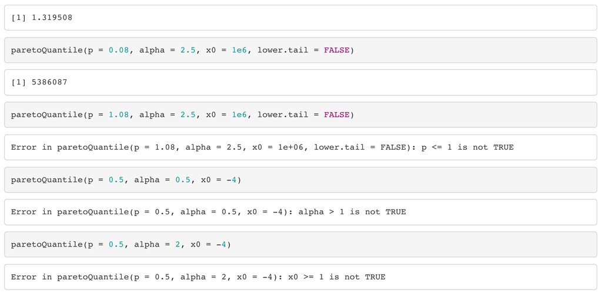